# Synthetic Data Comparison: INFO_USE

TIDES Wave 9 — News & Information Sources

Published

March 13, 2026

## Overview

This report compares real TIDES Wave 9 survey responses on news source usage against three synthetic generation approaches: **IRT** (Item Response Theory), **LLM** (Qwen3.5-9B via Together API), and **Agent-based simulation**.

The question asked respondents how often in the past month they got news from each of 11 sources, on a 1–5 scale (1 = Never, 5 = Multiple times/day).

|  | Real (n=2995) | IRT (n=11) | LLM (n=50) | Agent (n=50) |
| --- | --- | --- | --- | --- |
| N | 2995.00 | 11.00 | 50.00 | 50.00 |
| Grand mean | 2.63 | 2.55 | 1.01 | 2.54 |
| Grand SD | 1.25 | 0.81 | 0.05 | 1.31 |

## Mean Responses by Source

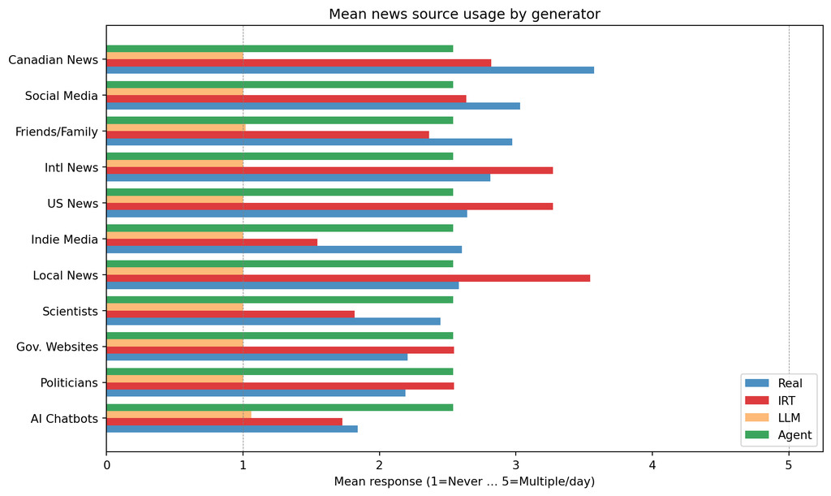

Table 1: Mean responses (1–5) by source and generator

|  | Real | IRT | LLM | Agent |
| --- | --- | --- | --- | --- |
| AI Chatbots | 1.840000 | 1.730000 | 1.060000 | 2.540000 |
| Politicians | 2.190000 | 2.550000 | 1.000000 | 2.540000 |
| Gov. Websites | 2.210000 | 2.550000 | 1.000000 | 2.540000 |
| Scientists | 2.450000 | 1.820000 | 1.000000 | 2.540000 |
| Local News | 2.580000 | 3.550000 | 1.000000 | 2.540000 |
| Indie Media | 2.600000 | 1.550000 | 1.000000 | 2.540000 |
| US News | 2.640000 | 3.270000 | 1.000000 | 2.540000 |
| Intl News | 2.810000 | 3.270000 | 1.000000 | 2.540000 |
| Friends/Family | 2.970000 | 2.360000 | 1.020000 | 2.540000 |
| Social Media | 3.030000 | 2.640000 | 1.000000 | 2.540000 |
| Canadian News | 3.570000 | 2.820000 | 1.000000 | 2.540000 |

## Response Distributions

Distribution of responses (%) for each source, comparing Real vs. synthetic generators.

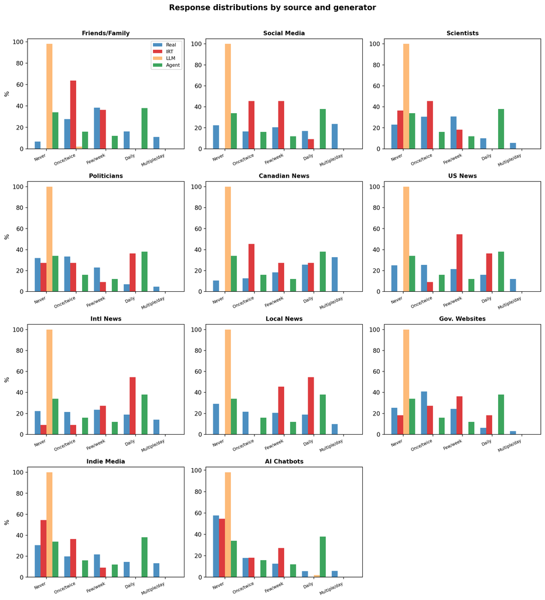

## Standard Deviations

Higher SD indicates the generator produces meaningful variance across respondents. Real SD is ~1.0–1.5 for all items.

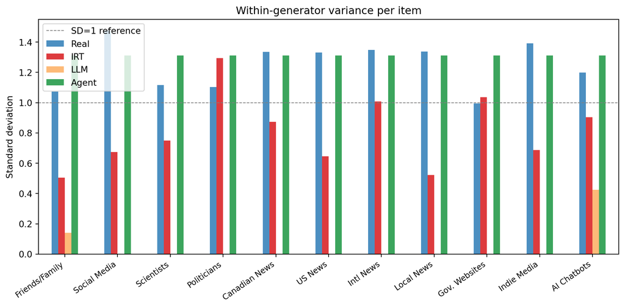

## Correlation Structure

How well does each generator preserve the inter-item correlation matrix of the real data?

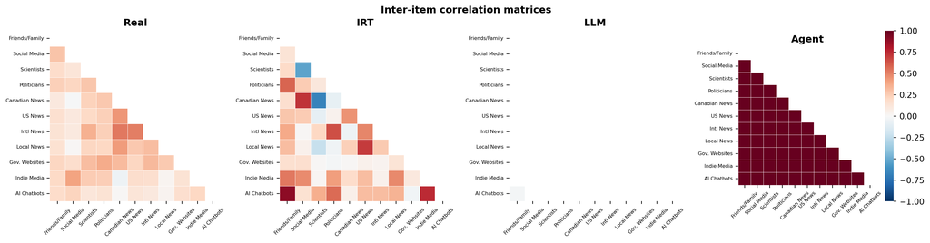

## K-Means Clustering (k=3)

K-means with k=3 applied independently to each dataset. Cluster centres show the “news diet profile” for each group.

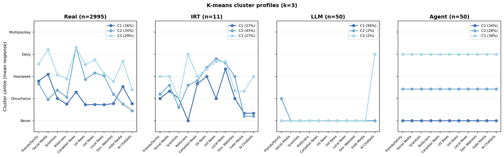

**Cluster interpretation:**

**Real**

- Cluster 1 (36%): avg=2.11 — highest: Social Media (3.1), Friends/Family (2.8)
- Cluster 2 (34%): avg=2.53 — highest: Canadian News (4.3), Intl News (3.2)
- Cluster 3 (29%): avg=3.39 — highest: Canadian News (4.3), Social Media (4.2)

**IRT**

- Cluster 1 (27%): avg=2.09 — highest: Local News (3.3), US News (3.0)
- Cluster 2 (45%): avg=2.55 — highest: Intl News (3.8), Local News (3.6)
- Cluster 3 (27%): avg=3.03 — highest: Politicians (4.0), Intl News (3.7)

**LLM**

- Cluster 1 (96%): avg=1.00 — highest: Friends/Family (1.0), Social Media (1.0)
- Cluster 2 (2%): avg=1.09 — highest: Friends/Family (2.0), Social Media (1.0)
- Cluster 3 (2%): avg=1.27 — highest: AI Chatbots (4.0), Friends/Family (1.0)

**Agent**

- Cluster 1 (34%): avg=1.00 — highest: Friends/Family (1.0), Social Media (1.0)
- Cluster 2 (28%): avg=2.43 — highest: Friends/Family (2.4), Social Media (2.4)
- Cluster 3 (38%): avg=4.00 — highest: Friends/Family (4.0), Social Media (4.0)

## Summary

| Dimension | Real | IRT | LLM | Agent |
| --- | --- | --- | --- | --- |
| Mean range across items | 1.8–3.6 | 1.6–3.6 | ~1.0 | 2.54 (flat) |
| Mean SD across items | ~1.2 | ~0.9 | ~0.01 | 1.31 (uniform) |
| Cluster differentiation | ✅ Rich | ⚠ Thin sample | ❌ Degenerate | ⚠ Intensity only |
| Preserves item ordering | — | Partial | No | No |

**IRT** produces the most realistic item-level ordering but only 11 of 50 personas generated valid (1–5) responses — a generator bug worth fixing.

**LLM** (Qwen3.5-9B) collapsed to near-constant “Never” responses. The persona narratives contain no news consumption cues, so the model defaults to the low end. Adding relevant traits (media habits, political engagement) to personas should improve this substantially.

**Agent** simulation converges to a uniform intensity level, applying the same opinion value to every item. It needs item-specific initial opinions seeded from persona traits to reproduce cross-source variation.